# A2 Visualizing Amounts

Luke Ghallahorne

2024-10-09

```r
# Library
library(tidyverse)
# dplyr, ggplot2, etc.
library(PNWColors)
# creates nice color palettes
library(scales)
# scales package for label_wrap()
```

```r
# create color palette for plots
pal1 <- pnw_palette("Starfish", n = 500)
```

# Precipitation Data

```r
# Load data
ppt <- read.csv("meanDivPcp1901-2000.csv")
```

```r
# examine data
head(ppt)
```

```
##   Location.ID                           Location inches
## 1         101      Alabama CD 1. Northern Valley  53.97
## 2         102 Alabama CD 2. Appalachian Mountain  55.27
## 3         103         Alabama CD 3. Upper Plains  55.12
## 4         104       Alabama CD 4. Eastern Valley  54.15
## 5         105     Alabama CD 5. Piedmont Plateau  54.00
## 6         106              Alabama CD 6. Prairie  53.03
```

```r
tail(ppt)
```

```
##     Location.ID                                             Location inches
## 339        4805 Wyoming CD 5. Powder, Little Mo and Tongue Drainages  15.29
## 340        4806                 Wyoming CD 6. Belle Fourche Drainage  16.35
## 341        4807             Wyoming CD 7. Cheyenne Niobrara Drainage  14.31
## 342        4808                           Wyoming CD 8. Lower Platte  14.88
## 343        4809                             Wyoming CD 9. Wind River  14.94
## 344        4810                          Wyoming CD 10. Upper Platte  13.19
```

## Data Wrangling

*Goal:* to include further description variables to each location for better visualization.

```r
# separate location column into State and ClimateDivision
ppt <- ppt %>% separate(col = Location,
                        into = c("State", "ClimateDivision"),
                        sep = " CD ")
```

```r
# create df of State Name, Region, Division, Area, and Abbreviations from base R objects
stateLookup <- tibble(State = state.name,
                      Region = state.region,
                      Division = state.division,
                      Area = state.area,
                      Abbv = state.abb)
```

```r
# join dfs by State variable in stateLookup
ppt <- ppt %>% inner_join(stateLookup, by = join_by(State))
head(ppt)
```

```
##   Location.ID   State         ClimateDivision inches Region           Division
## 1         101 Alabama      1. Northern Valley  53.97  South East South Central
## 2         102 Alabama 2. Appalachian Mountain  55.27  South East South Central
## 3         103 Alabama         3. Upper Plains  55.12  South East South Central
## 4         104 Alabama       4. Eastern Valley  54.15  South East South Central
## 5         105 Alabama     5. Piedmont Plateau  54.00  South East South Central
## 6         106 Alabama              6. Prairie  53.03  South East South Central
##    Area Abbv
## 1 51609   AL
## 2 51609   AL
## 3 51609   AL
## 4 51609   AL
## 5 51609   AL
## 6 51609   AL
```

# Visualizations

I want to compare the three states in which I have lived: Colorado, Vermont, and Washington. They have rather different climates so I want to examine their average precipitation across climate divisions as well as the number of distinct climate divisions in each. Washington and Colorado are roughly the same size but I expect will differ the most in precipitation, while Vermont is tiny, so will have far less total precipitation but be closer to Washington in average.

## Figure 1: Precipitation

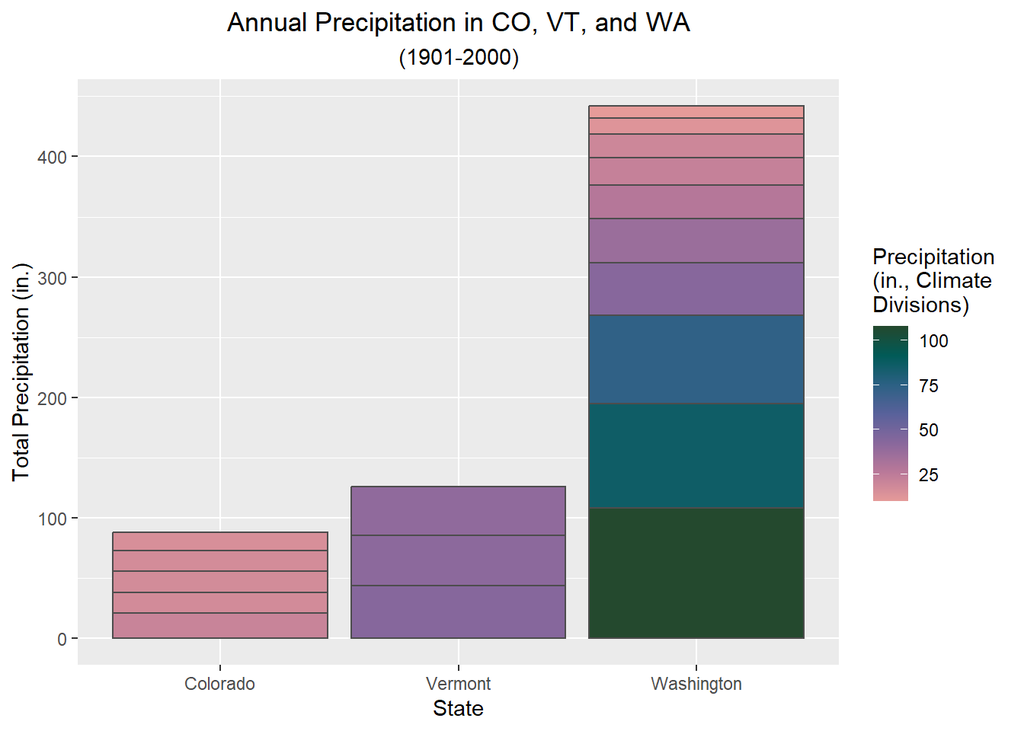

```r
# 3 States precipitation
ppt_3 <- ppt %>%
  # filter for WA, CO, and VT only
  filter(State %in% c("Washington", "Colorado", "Vermont")) %>%
  # rearrange df by State, then by inches (descending)
  arrange(State, desc(inches))

# save figure
fig1 <- ggplot(data = ppt_3, aes(x = State, y = inches, fill = inches)) +
  # create stacked columns by State with grey outline around climate divisions
  geom_col(position = "stack", color = "grey30") +
  # apply custom palette
  scale_fill_gradientn(colors = rev(pal1)) +
  # center title and subtitle
  theme(plot.title = element_text(hjust = 0.5), plot.subtitle = element_text(hjust = 0.5)) +
  # change labels
  labs(x = "State",
       y = "Total Precipitation (in.)",
       title = "Annual Precipitation in CO, VT, and WA",
       subtitle = "(1901-2000)",
       # the \n below in text creates a linebreak in ggplot
       fill = "Precipitation \n(in., Climate \nDivisions)")
# print figure
fig1
```

Figure 1: Average annual precipitation for Colorado, Vermont, and Washington (1901 - 2000). Colored bands represent the annual precipitation in each climate division within a state.

## Figure 2: Area

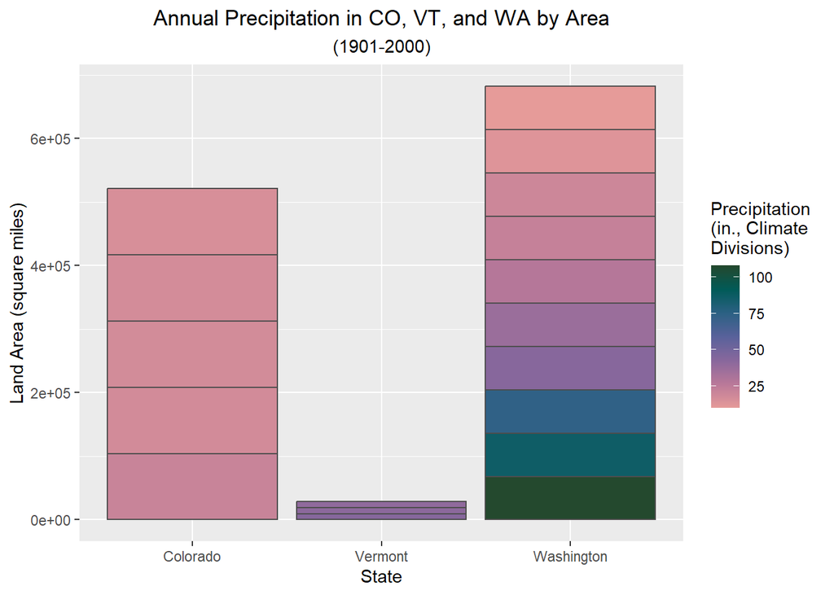

```r
# save new figure - all code the same, except y = Area instead of inches
fig2 <- ggplot(data = ppt_3, aes(x = State, y = Area, fill = inches)) +
  geom_col(position = "stack") +
  geom_col(position = "stack", color = "grey30", alpha = 0) +
  scale_fill_gradientn(colors = rev(pal1)) +
  theme(plot.title = element_text(hjust = 0.5), plot.subtitle = element_text(hjust = 0.5)) +
  labs(x = "State",
       y = "Land Area (square miles)",
       title = "Annual Precipitation in CO, VT, and WA by Area",
       subtitle = "(1901-2000)",
       fill = "Precipitation \n(in., Climate \nDivisions)")
fig2
```

Figure 2: Land area and average annual precipitation for Colorado, Vermont, and Washington (1901 - 2000). Colored bands represent the annual precipitation in each climate division within a state.

There is no information in the original dataset on how large each climate division is (and I didn’t quite want to wrangle with NOAA datasets to find it), so the sizes of the colored bands in Figure 2 do not correspond to areas of climate divisions. Comparing the two plots, I’m a little shocked that Vermont gets more total precipitation than Colorado, despite being immensely smaller.

# All States by Division

So here, I went a little bit overboard trying to visualize the total precipitation across all states by division and region.

```r
# rearrange by geographic division, then state (descending), then inches (descending)
ppt <- ppt %>%
  arrange(Division, desc(State), desc(inches))

# create new summary df
## summarized by state
## new variables: total inches, average inches, average inches per 1000m, state stats
## added a few variables to throw into the final plot and see which was more interesting to look at
ppt_tots <- ppt %>%
  group_by(State) %>%
  summarize(tot_inches = sum(inches), Area = mean(Area)) %>%
  mutate(avg_inches = tot_inches / Area) %>%
  mutate(avg_1000m = avg_inches * 1000) %>%
  inner_join(stateLookup[,c(1:3,5)], by = join_by(State)) %>%
  arrange(Division, desc(State))
```

```r
# Here, I create new variables to get the state labels in the right place
## the base idea is adding the value of the previous label, plus 1/2 the current division's value and 1/2 of the next division's value
## given that each value depends on the calculation of the previous, I used a few for-loops; there might be a more efficient tidyverse method to get the values that I wanted, but it was a very fast loop and I called that good enough.

# create label vector
ppt_labs <- vector()
## this loop uses a growing vector, which is not good practice typically, but it was the easiest option for this circumstance and did not add any significant processing time
for (i in 1: length(unique(ppt_tots$Division))) { # for each State division
  foo <- filter(ppt_tots, Division == unique(ppt_tots$Division)[i]) # filter ppt_tots by division
  bar <- matrix(nrow = nrow(foo), ncol = 1) # create empty matrix for values
  for (j in 1: nrow(foo)) { # for each Climate Division within the State Division
    bar[j] <- sum(bar[j-1], 0.5*foo$tot_inches[j-1],  0.5*foo$tot_inches[j])
    # add previous label's height to 1/2 last CD's tot_inches and 1/2 next CD's tot_inches
  }
  ppt_labs <- c(ppt_labs, bar) # add new labels to growing label vector
}
ppt_tots$label <- ppt_labs # save labels to ppt_tots dataframe

# repeat the above steps for labels on the Area plot
ppt_labsA <- vector()
for (i in 1: length(unique(ppt_tots$Division))) {
  foo <- filter(ppt_tots, Division == unique(ppt_tots$Division)[i])
  bar <- matrix(nrow = nrow(foo), ncol = 1)
  for (j in 1: nrow(foo)) {
    bar[j] <- sum(bar[j-1], 0.5*foo$Area[j-1],  0.5*foo$Area[j])
  }
  ppt_labsA <- c(ppt_labsA, bar)
}
ppt_tots$labelA <- ppt_labsA

# this loop divides the total state area by the number of Climate Divisions in that state
ppt_Area_avg <- vector()
for(i in 1:length(unique(ppt$State))) { # for each State
  foo <- filter(ppt, State == unique(ppt$State)[i]) # filter ppt by State
  bar <- as.vector(rep(foo$Area[1]/nrow(foo), nrow(foo))) # divide total area by number of CD's and repeat for new vector
  ppt_Area_avg <- c(ppt_Area_avg, bar) # add new values to growing vector
}
ppt$Area.avg <- ppt_Area_avg # assign to new column in ppt dataframe
# use merge() to be specific about where in the dataframe the new column arrives - using $ just adds the new column to the right-hand side
```

## Figure 3: Precipitation

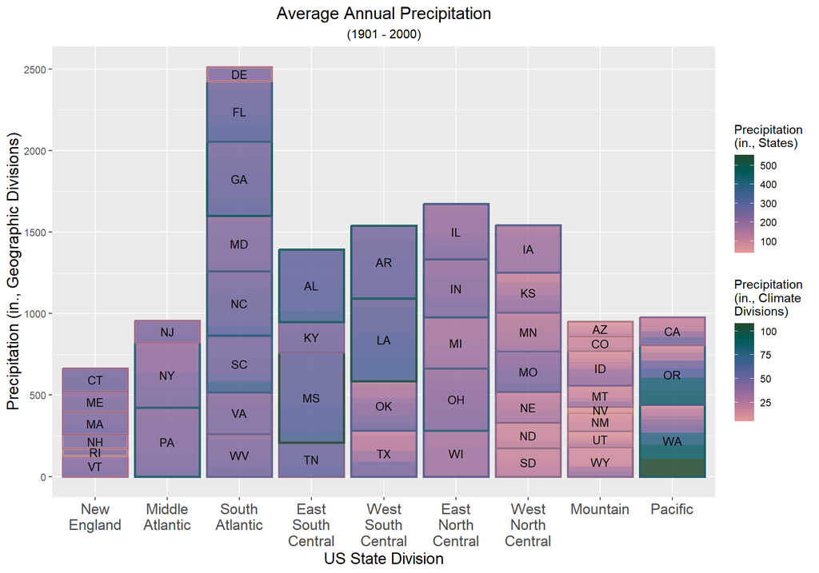

```r
# save plot - starting with empty ggplot() b/c adding multiple layers with different source dataframes
fig3 <- ggplot() +
  # stacked bar plot columns by State Division
  geom_col(data = ppt, aes(x = Division, y = inches, fill = inches),
           position = "stack", alpha = 0.85) +
  # apply custom palette
  scale_fill_gradientn(colors = rev(pal1)) +
  # stacked bar plot of State total precip by Division
  ## change border color to State total precip
  ## will overlay previous barplot (alpha = 0) but show the total precip for the whole state
  geom_col(data = ppt_tots,
           aes(x = Division, y = tot_inches, color = tot_inches),
           alpha = 0, linewidth = 1) +
  # add the same layer but thin black lines, for clarity
  geom_col(data = ppt_tots, aes(x = Division, y = tot_inches),
           color = "gray40", alpha = 0, linewidth = 0.25) +
  # apply custom palette
  scale_color_gradientn(colors = rev(pal1)) +
  # force x-axis labels to wrap after 10 characters (req. scales package)
  scale_x_discrete(labels = label_wrap(10),
                #   guide = guide_axis(n.dodge = 2)
                ## use this to dodge x-axis labels instead of wrapping
                   ) +
  # add State abbreviation labels
  geom_text(data = ppt_tots, aes(x = Division, y = label, label = Abbv), size = 3.5) +
  # adjust x-axis text size
  theme(axis.text.x = element_text(size = 13),
        plot.title = element_text(hjust = 0.5, size = 15),
        plot.subtitle = element_text(hjust = 0.5),
        axis.title = element_text(size = 14)) +
  # change labels (/n adds linebreaks to text)
  labs(x = "US State Division",
       y = "Precipitation (in., Geographic Divisions)",
       title = "Average Annual Precipitation",
       subtitle = "(1901 - 2000)",
       fill = "Precipitation \n(in., Climate \nDivisions)",
       color = "Precipitation \n(in., States)")

fig3
```

Figure 3: Average annual precipitation in US states, grouped by state division. Colored bars within each state represent annual precipitation across the state’s climate divisions. Colored borders around each state express the total precipitation for the entire state.

## Figure 4: Area

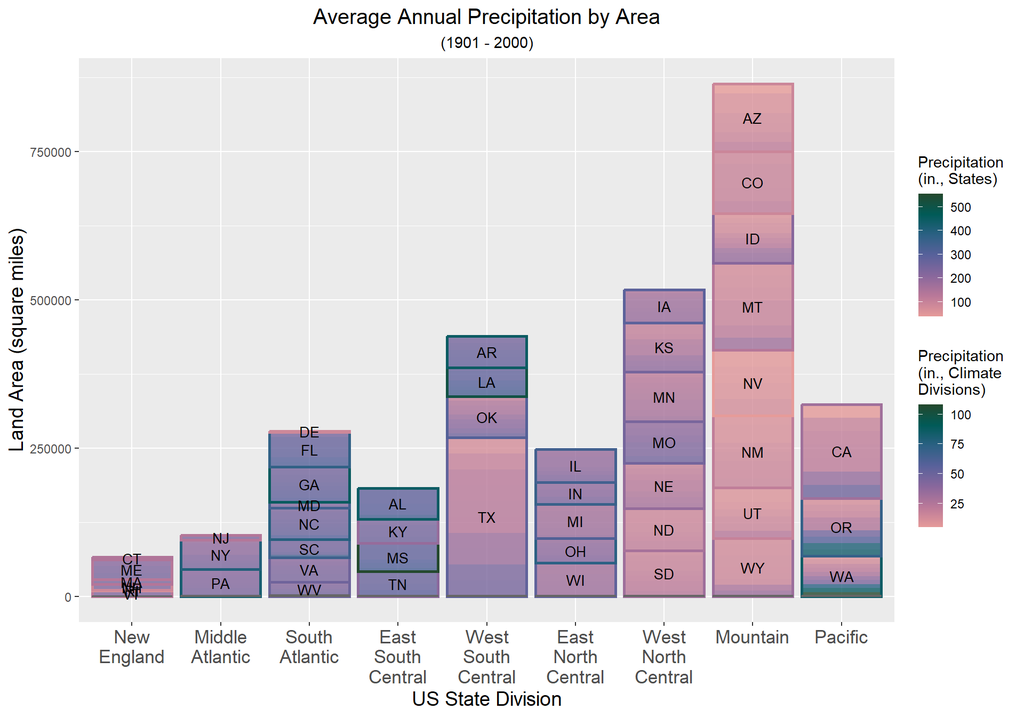

```r
# copied code from previous plot, but changed y = Area.avg, y = Area, and y = labelA for area plot
# save plot - starting with empty ggplot() b/c adding multiple layers with different source dataframes
fig4 <- ggplot() +
  # stacked bar plot columns by State Division
  geom_col(data = ppt, aes(x = Division, y = Area.avg, fill = inches),
           position = "stack", alpha = 0.8) +
  # apply custom palette
  scale_fill_gradientn(colors = rev(pal1)) +
  # stacked bar plot of State total precip by Division
  ## change border color to State total precip
  ## will overlay previous barplot (alpha = 0) but show the total precip for the whole state
  geom_col(data = ppt_tots,
           aes(x = Division, y = Area, color = tot_inches),
           alpha = 0, linewidth = 1) +
  # add the same layer but thin black lines, for clarity
  geom_col(data = ppt_tots, aes(x = Division, y = tot_inches),
           color = "gray40", alpha = 0, linewidth = 0.5) +
  # apply custom palette
  scale_color_gradientn(colors = rev(pal1)) +
  # force x-axis labels to wrap after 10 characters (req. scales package)
  scale_x_discrete(labels = label_wrap(10),
                #   guide = guide_axis(n.dodge = 2)
                ## use this to dodge x-axis labels instead of wrapping
                   ) +
  # add State abbreviation labels
  geom_text(data = ppt_tots, aes(x = Division, y = labelA, label = Abbv), size = 3.5) +
  # adjust x-axis text size
  theme(axis.text.x = element_text(size = 13),
        plot.title = element_text(hjust = 0.5, size = 15),
        plot.subtitle = element_text(hjust = 0.5),
        axis.title = element_text(size = 14)) +
  # change labels (/n adds linebreaks to text)
  labs(x = "US State Division",
       y = "Land Area (square miles)",
       title = "Average Annual Precipitation by Area",
       subtitle = "(1901 - 2000)",
       fill = "Precipitation \n(in., Climate \nDivisions)",
       color = "Precipitation \n(in., States)")

fig4
```

Figure 4: Land area and average annual precipitation for US states by state division. Y-axis depicts the total land area for each division. Colored bands within each state represent annual precipitation for each of the state’s climate divisions. Colored borders around each state depict the total precipitation for the entire state.

There is some unwanted overlapping in the labels for New England because the states are so small compared to other divisions. I couldn’t get the labels to dodge correctly in the y-direction, so I would need to change the coordinates for the labels manually. Since the precipitation plot (figure 3) feels like the most complete and most informative, however, I didn’t go all the way with correcting these labels.